# Отчет

## Постановка задачи

Мной были выполнены 2 задачи: Beginner и Intermidiate. Требовалось:

для файлов Group_*.bmp :

1. Определить количество фишек на изображении
2. Определить расположение и номера всех фишек в кадре.

для файлов Single_*.bmp :

1. Определить тип и цвет линий на фишке – короткая дуга большой кривизны, длинная дуга малой кривизны, прямолинейный сегмент.
2. Определить номер фишки

## Входные данные

представляют собой картинки в формате .bmp, на которых изображены(а) фишки(а) игрового набора Тантрикс. С помощью библиотеки skimage мы считываем их и в программе работаем с тензорами размера $N \times M \times 3 $ с помощью библиотеки numpy.

## Описание метода решения

### Бинаризация изображения

Первым действием - бинаризуем изображение. Это необходимо, чтобы выделить все фишки на изображении и понять их границы. Далее будем считать, что у нас есть и бинаризованное изображение и цветное, причем пиксели соответствуют друг другу однозначно на этих изображениях.

Теперь опишем алгоритм для определения номера одной фишки. На вход ему подается бинаризованное и цветное изображения

### Алгоритм для определения номера одной фишки

Алгоритм распознавания фишки основан, во-первых, на геометрических приобразованиях (поворотах фишки), а, во-вторых, на распознавании цвета отдельных пикселей (для определения того, линия какого цвета входит в грань.

1. Находим крайнюю правую, крайнюю левую и самую нижнюю точки, принадлежащие фишке по биноризованному изображению.
2. Находим расстояние от нижней точки - до левой и правой крайних точек соответсвенно. Если расстоние до какой-то "сильно больше", то считаем, что фишка повернута в определенную сторону.
3. Если фишка повернута, то находим длину стороны этой фишки (в масштабе картинки) как расстояние от нижней точки до центра (центр находится как центр масс пикселей, принадлежащих фишке). Находим угол, на который надо повернуть фишку, чтобы ее нижняя сторона стала "cтрого параллельна оси OX"
4. Теперь будем поворачивать фишку на 60, 120, 180 и тд градусов, чтобы каждая ее сторона последовательно становилась параллельно оси Ox.
5. Для каждого такого положения мы вырезаем небольшие области цветного изображения, прилегающие к нижней стороне фишки и выясняем количество пикселей красного, желтого и черного цвета (мы не делаем различия между черным и синим цветами, так как их крайне сложно отличить). Чтобы распознать цвет пикселя для каждого канала мы эмпирически устанавливаем "контрольные значения" и считаем, что если отклонение по всем каналам от контрольных значений красного цвета мало, то пиксель красного цвета, если желтого, то соответственно желтого и тд.
6. Мы смотрим пикселей какого цвета больше на вырезанном фрагменте, и делаем вывод о том, дуга какого цвета входит в эту сторону (пикселей черного цвета всегда будет наибольшее количество, поэтому мы определяем фишку красной или желтой, если пикселей этого цвета больше некого относительного порога).
7. Назначаем цвета всех сторон фишки и находим фишку из данных, у которой цвета сторон идут в том же порядке. Таким образом мы классифицируем фишку. Если нам не удалось определить цвет какой-то одной стороны - это не мешает нам определить номер фишки.

Основная идея алгоритма - фишка однозначно определяется по цвету 5 ребер (под цветом ребра мы подразумеваем цвет линии, которая в него входит)

## Описание программной реализации

Алгоритмы реализованы на языке python при использовании множества функций из библиотек scipy и skimage для работы с изображениями. Далее для каждого пункта алгоритмов, описанных выше, будет показано, какие функции использовались

### Алгоритм для определения номера одной фишки

1. ф-ция get_extreme(indexes) - просто максимальные и минимальные значения координат пикселей, принадлежащих фишке
2. get_3_vertexes(indexes) - используем евклидово расстояние ан плоскости
3. what_side(points, indexes, inplace=True), get_angle_and_bottom_offset(cropped_img, bottom_vertex, closer_to_right) и др - из соображений аналитической геометрии и знаний о правильном треугольнике находим интересующий угол
4. get_one_chip(img, show=False) - основная функция
5. cut_fragment(img_rotated, bottom_offset), detect_colour(pixel) и др. - из геометрических соображений вырезаем нужный кусок и для каждого пикселя определяем цвет
6. colours_in_fragment(fragment, return_distinct_img) - определяем цвета всех пикселей и делаем вывод о цвете ребра
7. recognize_chip(str_code, return_lines=False) - кодируем цвета сторон фишки как строку и с помощью библиотеки re и циклического сдвига определяем какой номер анализируемой фишки

### Алгоритм для определения всех фишек

1. skimage.filters.threshold_otsu, scipy.ndimage.measurements.label - помогают нам бинаризовать и выделить связные комоненты
2. scipy.ndimage.morphology.binary_fill_holes, skimage.segmentation.clear_border - позволяют нам избавиться от артефактов
3. get_all_chips(img_group, plot_every_chip=False) - основная функция для обработки группового изображения

## Эксперименты

В качестве эксперимента рассмотрим работу алгоритма на файле Group_2 со всеми промежуточными выкладками. Для каждой фишки можно увидеть ее не повернутое положение, повороты на все нужные углы, а для каждого поворота - вырезвнный фрагмент и то, как на нем юыли распознаны пиксели

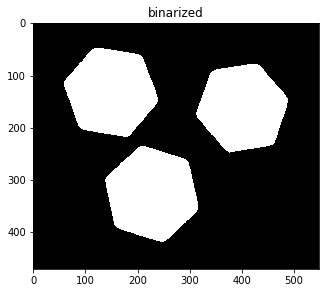

[figure not shown]

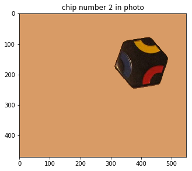

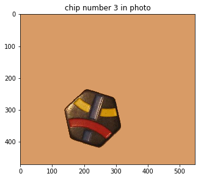

[figure not shown]

[figure not shown]

```
yellow: 0  red: 0  black: 1530
relative yellow: 0.0, relative red: 0.0
```

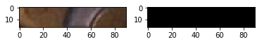

```
this side is recognized as blue
```

[figure not shown]

```
yellow: 216  red: 1  black: 1313
relative yellow: 0.16450875856816452, relative red: 0.0007616146230007616
```

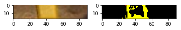

```
this side is recognized as yellow
```

[figure not shown]

```
yellow: 0  red: 364  black: 1166
relative yellow: 0.0, relative red: 0.31217838765008576
```

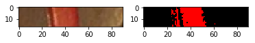

```
this side is recognized as red
```

[figure not shown]

```
yellow: 390  red: 1  black: 1139
relative yellow: 0.3424056189640035, relative red: 0.000877963125548727
```

[32 more figures not shown]

```python
img_group = read_img('group', 'Group_2.bmp')
solve_problem(img_group, problem_all_chips_class)
```

Также продемонстрируем работу для других задач

```python
img_group = read_img('group', 'Group_4.bmp')
solve_problem(img_group, problem_num_chips)
```

```
There is 10 chips in the picture
```

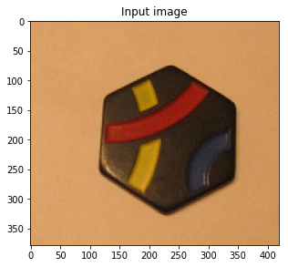

```
Number of chip is 7
```

```python
img = read_img('single', 'Single_2.bmp')
io.imshow(img)
plt.title('Input image')
plt.show()
solve_problem(img, problem_what_chip)
```

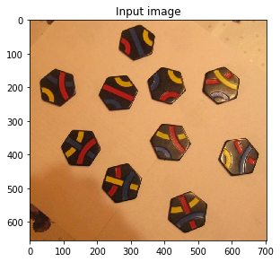

```python
img = read_img('group', 'Group_4.bmp')
io.imshow(img)
plt.title('Input image')
plt.show()
solve_problem(img, problem_num_chips)
```

[output not shown]

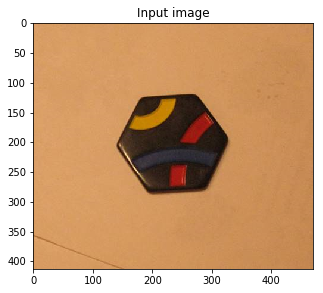

```
Number of chip is 10
```

```python
img = read_img('single', 'Single_1.bmp')
io.imshow(img)
plt.title('Input image')
plt.show()
solve_problem(img, problem_what_chip)
```

```python
img = read_img('single', 'Single_2.bmp')
io.imshow(img)
plt.title('Input image')
plt.show()
solve_problem(img, problem_what_chip)
```

[output not shown]

## Вывод

1. Были успешно решены все поставленные задачи и разработаны соответсвующие алгоритмы. При работе с группами объектов широко использовались библиотечный функции, в то время как почти все функции работы с одной фишкой были написаны и разработаны самостоятельно.
2. Алгоритм, решающий эту задачу, не являются универсальными и при изменении фона, добавлении шума, изменении освещения должны корректироваться. Например, если на картинке будет больше объектов, не являющихся фишками, нужно будет более тщательно избавляться от них.